# HW7

### Wei Chen, 5207679

### Q6.2

Using the information in Example 6.1. Construct the 95% Bonferroni simultaneous intervals for the components of the mean difference vector $\delta$. Compare the lengths of these intervals with those of te simultaneous intervals constrcuted n the example.

Solution:

```r
URL='http://users.stat.umn.edu/~guxxx192/courses/wichern_data/t6-1.dat'
wastewater=read.table(URL, col.names=c('comml.BOD','comml.SS','state.BOD','state.SS'))
Diff<-wastewater[,c(1,2)]-wastewater[,c(3,4)]
colnames(Diff)<- c('diff.BOD','diff.SS')
dbar<- colMeans(Diff)
Sd<-cov(Diff)
n<-nrow(Diff)
p<-ncol(Diff)
mu0<-c(0,0)
alpha<-1-0.95
radius<-qt(alpha/(2*p),df=n-1,lower.tail=FALSE)
print(lower_bon_w<- dbar-radius*sqrt(diag(Sd)/n))
```

```
##   diff.BOD    diff.SS
## -20.573107  -2.974903
```

```r
print(upper_bon_w<-dbar+radius*sqrt(diag(Sd)/n))
```

```
##  diff.BOD   diff.SS
##  1.845835 29.520358
```

We find that 95% T<sup>2</sup> simultaneous intervals is wider than 95% Bonferroni simultaneous intervals.

### Q6.3

The data corresponding to sample 8 in Table 6.1 seem unusually large. Remove sample 8. Construct a joint 95% confidence region for the mean difference vector $\delta$ and the 95% Bonferroni simultaneous intervals for the components of the mean difference vector. Are the results consistent with a test of H<sub>0</sub>: $\delta$? Discuss. DOes the ‘outlier’ make a difference in the analysis of these data?  
Solution:

```r
newDiff<-Diff[-8,]
new_dbar<-colMeans(newDiff)
newSd<- cov(newDiff)
new_n<-nrow(newDiff)
new_p<-ncol(newDiff)
radius_bon_new_w<-qt(alpha/(2*new_p),df=new_n-1, lower.tail=FALSE)
print(lower_bon_new_w<- new_dbar- radius_bon_new_w*sqrt(diag(newSd)/new_n))
```

```
##   diff.BOD    diff.SS
## -21.917997  -3.355587
```

```r
print(upper_bon_new_w<- new_dbar+ radius_bon_new_w*sqrt(diag(newSd)/new_n))
```

```
##  diff.BOD   diff.SS
## -2.082003 20.555587
```

```r
radius_T2_new_w<-sqrt(new_p*(new_n-1)/(new_n-new_p)*qf(alpha, df1=new_p, df2=new_n-new_p,lower.tail=FALSE))
print(lower_T2_new_w<- new_dbar-radius_T2_new_w*sqrt(diag(newSd)/new_n))
```

```
##   diff.BOD    diff.SS
## -23.700016  -5.503711
```

```r
print(upper_T2_new_w<- new_dbar+radius_T2_new_w*sqrt(diag(newSd)/new_n))
```

```
##   diff.BOD    diff.SS
## -0.2999837 22.7037107
```

After removing the sample 8, the simultaneous intervals of both T<sup>2</sup> and Bonferroni no longer cover [0,0]. So we need to reject the null hypothesis and yes, the “outlier” Does make a difference during the analysis.

### Q6.4

Refer to Example 6.1 (a)Redo the analysis in Example 6.1 after transforming the pairs of observations to ln(BOD) and ln(SS)  
(b)Construct the 95% Bonferroni simultaneous intervals for the components of the mean vector $\delta$ of transformed variables  
(c)Discuss any possible violation of the assumption of a bivariate normal distribution for the difference vectors of transformed observations.

Solution:  
(a)

```r
wastewater<-log(wastewater)
Diff<-wastewater[,c(1,2)]-wastewater[,c(3,4)]
dbar<- colMeans(Diff)
Sd<-cov(Diff)
n<-nrow(Diff)
p<-ncol(Diff)
mu0<-c(0,0)
alpha<-1-0.95
radius_T2<- sqrt(p*(n-1)/(n-p)*qf(alpha, df1=p,df2=n-p, lower.tail=FALSE))
print(lower_T2<-dbar-radius_T2*sqrt(diag(Sd)/n))
```

```
##  comml.BOD   comml.SS
## -1.1844404 -0.1020988
```

```r
print(upper_T2<-dbar+radius_T2*sqrt(diag(Sd)/n))
```

```
## comml.BOD  comml.SS
## 0.0680501 0.6931554
```

```r
radius_bon<-qt(alpha/(2*p),df=n-1,lower.tail=FALSE)
print(lower_bon_w<- dbar-radius_bon*sqrt(diag(Sd)/n))
```

```
##   comml.BOD    comml.SS
## -1.09448795 -0.04498455
```

```r
print(upper_bon_w<-dbar+radius_bon*sqrt(diag(Sd)/n))
```

```
##   comml.BOD    comml.SS
## -0.02190232  0.63604112
```

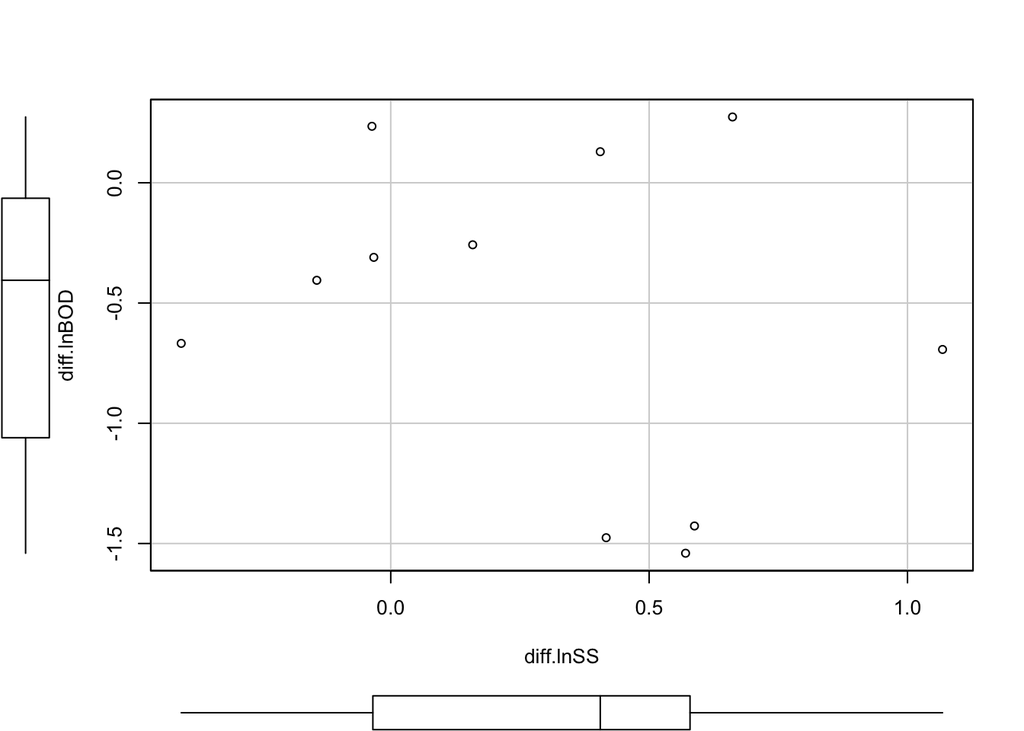

```r
library(car)
colnames(Diff)<- c('diff.lnBOD','diff.lnSS')
#dev.off()
scatterplot(diff.lnBOD ~diff.lnSS, data=Diff, smoother=FALSE, reg.line=FALSE)
```

Note that scatterplot of paired variables is not elliptical shape which implies it violates bivariate normality.  
### Q6.9 Using the constrast matrix C in (6-13), verify the relationships d<sub>j</sub>=Cx<sub>j</sub>, $\bar{d}$=C$\bar{x}$, and S<sub>d</sub>=CSC’ in (6-14)

Solution:
(1) First we prove $\left[ \begin{array}{cc} d_{1} & \dots & d_{j}& \dots & d_{N} \end{array} \right]$=$D_{p*N}$=$C_{p*2p}$$X_{2p*N}$= $C_{p*2p}$$\left[ \begin{array}{c} X^{treat1}_{p*N} \\ X^{treat2}_{p*N} \end{array} \right]$, which means
$\left[ \begin{array}{cc} d_{1} & \dots & d_{j}& \dots & d_{N} \end{array} \right] = \begin{bmatrix} 1 & 0 & \dots & 0 &-1 & 0 &\dots & 0 \\ 0 & 1 & \dots & 0 &0 &-1 & \dots & 0 \\ \vdots & \vdots & \ddots & \vdots & \vdots & \vdots &\ddots &\vdots \\ 0 & 0 & \dots & 1 & 0 & 0 &\dots & -1 \end{bmatrix} \times \left[ \begin{array}{cc} x_{1} & \dots & x_{j}& \dots & x_{N} \end{array} \right] , x_{j} = \begin{bmatrix} x^{treat1}_{1j}\\ x^{treat1}_{2j}\\ \vdots \\ x^{treat1}_{pj}\\ x^{treat2}_{1j}\\ \vdots \\ x^{treat2}_{pj} \end{bmatrix}$ (2)
$\bar{d}=\frac{1}{N} \sum_{j}^{N} Cx_{j} =C(\frac{1}{N} \sum_{j}^{N} x_{j})= C \bar{x}$ (3) $S_{d}=cov(D)=cov(CX)=Ccov(S)C'=CSC'$

### Q6.11

A likelihood argument provides additional support for pooling the two independent sample covraince matrices to estimate a common covariance matrix in the case of two normal populations. Give the likelihood function, L($\mu_{1}$,$\mu_{2}$,$\Sigma$), for two independent samples of sizes n<sub>1</sub> and n<sub>2</sub> from N<sub>p</sub>($\mu_{1}$,$\Sigma$) and N<sub>p</sub>($\mu_{2}$,$\Sigma$) populations, repectively. Show that this likelihood is maximized by the choices $\hat{\mu_{1}}$=$\bar{x_{1}}$, $\hat{\mu_{2}}$=$\bar{x_{2}}$ and $\hat{\Sigma}$= $\frac{1}{n_{1}+n_{2}}$[$(n_{1}-1)S_{1}+(n_{2}-1)S_{2}$]= ($\frac{n_{1}+n_{2}-2}{n_{1}+n_{2}}$)$S_{pooled}$

Solution: